# Tarea 2 - Grupo 8

Patricio Durán - Andrés Carvacho

2025-08-28

El Comité Olímpico de una gran potencia del atletismo está estudiando el programa de entrenamiento de varones para la competencia de 100 metros planos, por lo que ha recopilado datos de una muestra aleatoria de atletas.

```r
#Se leen los datos de la matriz de datos
data <- read.csv("EP02 Datos.csv", header = TRUE, sep = ";") #Carga de datos
```

El Comité Olímpico cree que el mejor tiempo medio de los atletas de la zona Centro-Sur antes de ingresar al programa de entrenamiento era 19.4 segundos. ¿Soportan los datos esta afirmación? Para responder es necesario filtrar los datos, determinar la distribución de la muestra y por consecuencia la prueba a utilizar y determinar la hipótesis nula y alternativa.

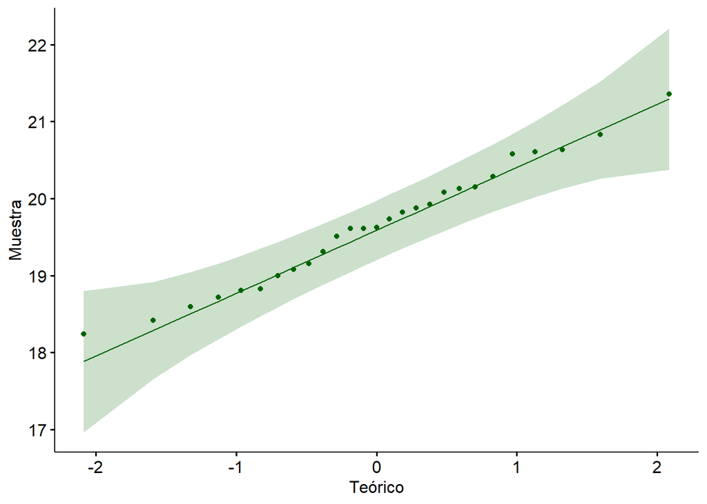

```r
#Se filtran los atletas por la zona Centro Sur
centroSur <- data %>% filter(Zona=="Centro-Sur")
#Se obtienen los tiempos previos
tiemposPrev <- as.numeric(lapply((centroSur$Previo), function(x) gsub(",", ".", x)))


#Se realiza un gráfico qq para visualizar la distribución de la muestra.
g <- ggqqplot(data = tiemposPrev,
                    xlab = "Teórico",
                    ylab = "Muestra",
                    color = "darkgreen",
                    alpha = 0.7)


print(g)
```

Aparentemente la muestra sigue una distribución normal, no obstante, un gráfico no es evidencia suficiente para asegurar normalidad, razón por la cual se aplican pruebas de normalidad a la muestra para así dar un veredicto.

```r
#Evaluación de normalidad para los datos
  #Pruebas de normalidad
  prueba1 = lillie.test(tiemposPrev)$p.value
  prueba2 = shapiro.test(tiemposPrev)$p.value
  print(prueba1)
```

```
## [1] 0.9724036
```

```r
  print(prueba2)
```

```
## [1] 0.9320262
```

El valor p obtenido de las pruebas es 0.97 y 0.93, los cuales son mayores al valor de significancia estándar de las pruebas de normalidad (0.05), por lo que no hay evidencia suficiente para rechazar la hipótesis nula, por ende, la distribución de la muestra es normal. Además, debido a que se tomó una muestra aleatoria de atletas, se puede decir que el tiempo de cada uno no afecta al resto, por lo tanto las observaciones son independientes entre sí. Debido a que se comprobó que los datos siguen una distribución normal, son independientes y que la muestra es menor a 30, se decide utilizar la prueba t para corroborar lo establecido por el comité.

$$H_0: \mu_\ =19.4$$

$$H_a: \mu \neq 19.4$$

```r
#Se define el valor nulo y el nivel de significancia
mu <- 19.4
alpha <- 0.05

#Se realiza la prueba T
pruebaT <- t.test(x = tiemposPrev, mu = mu, alternative = "two.sided", conf.level = 1 - alpha)
print(pruebaT)
```

```
##
##  One Sample t-test
##
## data:  tiemposPrev
## t = 1.6398, df = 26, p-value = 0.1131
## alternative hypothesis: true mean is not equal to 19.4
## 95 percent confidence interval:
##  19.33667 19.96295
## sample estimates:
## mean of x
##  19.64981
```

Dado que el valor p obtenido de la prueba t student es mayor al nivel de significancia propuesto, no hay evidencia suficiente para rechazar la hipótesis nula. Por lo tanto, se puede afirmar con 95% de confianza, que el mejor tiempo medio de los atletas de la zona Centro-Sur antes de ingresar al programa es de 19.4.

¿Sugieren los datos que la mejor marca de los atletas de la zona Sur se reduce en promedio 1.3 segundos tras el entrenamiento? En base al enunciado anterior, es necesario aislar los datos que se solicitan. Como se menciona, se debe corroborar que el tiempo medio de la diferencia de los tiempos de los atletas de la Zona Sur es 1.3 segundos, para ello primero se obtienen los tiempos de los atletas tal que son de la zona sur y luego se construye un vector con la diferencia de los tiempos de antes y después del entrenamiento.

```r
#Se filtran los tiempos previos y posteriores de los atletas de la zona sur
zonaSur <- data %>% filter(Zona=="Sur")
surPrevio <- as.numeric(lapply((zonaSur$Previo), function(x) gsub(",", ".", x)))
surPosterior <- as.numeric(lapply((zonaSur$Posterior), function(x) gsub(",", ".", x)))

diferenciaSur <- surPrevio - surPosterior #Se calcula la diferencia entre los tiempos
```

Con el vector construido, es necesario analizar la normalidad de los datos, para ello se grafica su distribución con un gráfico qq.

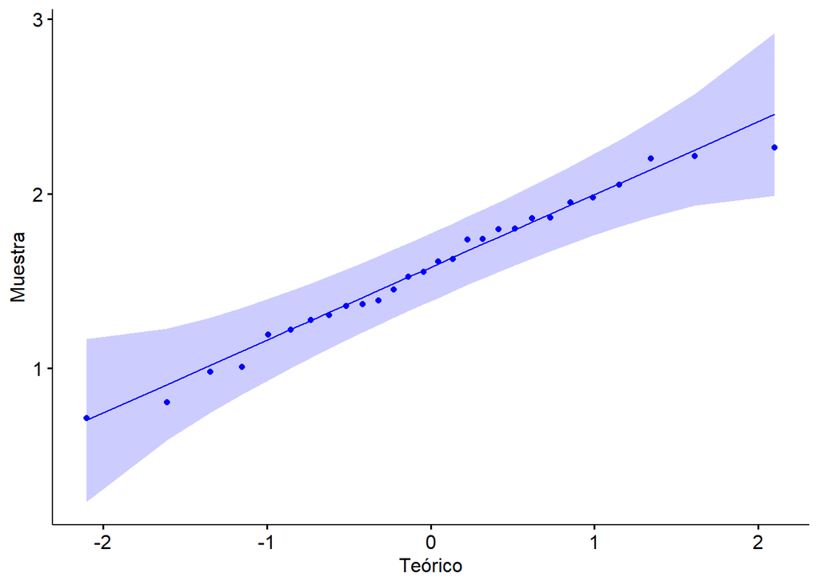

```r
#Gráfico QQ
g1 <- ggqqplot(data = diferenciaSur,
                    xlab = "Teórico",
                    ylab = "Muestra",
                    color = "blue",
                    alpha = 0.7)
print(g1)
```

El gráfico pareciera indicar normalidad, no obstante, una evidencia más sólida son pruebas de normalidad. Al igual que con la pregunta anterior, se usan las pruebas de shapiro y lillie para corroborar la normalidad.

```r
#Evaluación de normalidad para los datos
  #Pruebas de normalidad
  test1 = lillie.test(diferenciaSur)$p.value
  test2 = shapiro.test(diferenciaSur)$p.value
  print(test1)
```

```
## [1] 0.8381182
```

```r
  print(test2)
```

```
## [1] 0.802712
```

El valor p obtenido de las pruebas es 0.83 y 0.8, los cuales son mayores al valor de significancia estándar de las pruebas de normalidad (0.05), por lo que no hay evidencia suficiente para rechazar la hipótesis nula, por ende, la distribución de la muestra es normal. A continuación se obtiene el número de muestras para finalmente determinar que tipo de prueba utilizar.

```r
print(length(diferenciaSur)) #Cantiadad de observaciones
```

```
## [1] 28
```

Como se puede observar, el tamaño de la muestra es de 28 observaciones. Adicionalmente la diferencia entre los tiempos previos y posteriores son independientes para cada atleta. Finalmente, en razón de que existe normalidad, las observaciones son independientes y hay menos de 30 observaciones, se decide utilizar una t.test para una muestra. Considerando las siguientes hipotésis:

$$H_0: \mu_\ = 1.3$$

$$H_a: \mu \neq 1.3$$

```r
#Se define el valor nulo y el nivel de significancia
mu1 <- 1.3
alpha1 <- 0.05

#Se realiza la prueba T
pruebaTSur <- t.test(diferenciaSur, mu = mu1, alternative = "two.sided", conf.level = 1 - alpha1)
print(pruebaTSur)
```

```
##
##  One Sample t-test
##
## data:  diferenciaSur
## t = 3.3703, df = 27, p-value = 0.002276
## alternative hypothesis: true mean is not equal to 1.3
## 95 percent confidence interval:
##  1.403949 1.727479
## sample estimates:
## mean of x
##  1.565714
```

El valor p obtenido de la prueba T resulta ser menor al nivel de significancia establecido, por lo tanto, se rechaza la hipótesis nula y se prioriza la hipotesis alternativa. En conclusión, se afirma con 95% de confianza que la mejor marca de los atletas de la zona Sur no se reduce en promedio 1.3 segundos tras el entrenamiento.

¿Es posible afirmar que, en promedio, los atletas de la zona Sur superan a los de la zona Centro-Sur por menos de 5.2 segundos antes del entrenamiento?

En el desarrollo de los ejercicios anteriores se habían filtrado los tiempos previos de los atletas de la zona Centro Sur y de la Zona Sur. Adicionalmente ya se comprobó la normalidad de la primera muestra, así que se procede con la verificación de normalidad de los tiempos previos de la zona Sur.

```r
centroSurPrev <- tiemposPrev #Se redefine la variable, para tener más claridad con los nombres
```

Se gráfica la distribución de la muestra y posteriormente se hacen pruebas de normalidad.

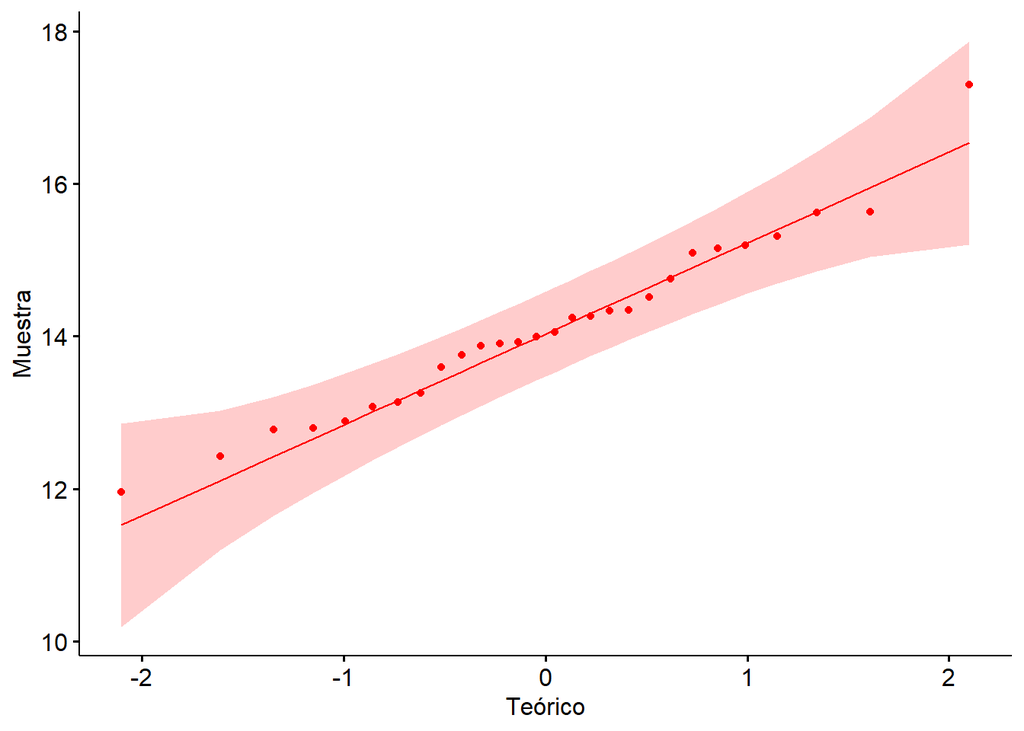

```r
#Gráfico QQ
g2 <- ggqqplot(data = surPrevio,
                    xlab = "Teórico",
                    ylab = "Muestra",
                    color = "red",
                    alpha = 0.7)
print(g2)
```

```r
#Evaluación de normalidad para los datos
  #Pruebas de normalidad
  test3 = lillie.test(surPrevio)$p.value
  test4 = shapiro.test(surPrevio)$p.value
  print(test3)
```

```
## [1] 0.699707
```

```r
  print(test4)
```

```
## [1] 0.6630897
```

Los resultados anteriores confirman la normalidad de la muestra y ambas muestras tienen observaciones independientes. Por lo que se decide aplicar una prueba t para dos muestras independientes. Para ello primero se debe comprobar que ambas muestras tienen varianzas iguales, razón por la cual se utiliza una prueba F de igualdad de varianzas.

```r
print(var.test(centroSurPrev, surPrevio)$p.value) #Valor p de la prueba F de igualdad de varianzas
```

```
## [1] 0.05910016
```

Las hipótesis a tratar son las siguientes:

Finalmente, como las varianzas son iguales, se utilizará el argumento extra de la función t.test para dos muestras independientes para varianzas agrupadas (var.equal = TRUE).

```r
t.test(centroSurPrev, surPrevio, mu = 5.2, alternative = "less", conf.level = 1 - 0.05, var.equal=TRUE) #Prueba T para dos muestras independientes
```

```
##
##  Two Sample t-test
##
## data:  centroSurPrev and surPrevio
## t = 1.2586, df = 53, p-value = 0.8932
## alternative hypothesis: true difference in means is less than 5.2
## 95 percent confidence interval:
##      -Inf 5.984747
## sample estimates:
## mean of x mean of y
##  19.64981  14.11304
```

El valor p obtenido (0.8932) de la prueba T es mayor que el nivel de significancia establecido, lo que indica que no hay suficiente evidencia para rechazar la hipótesis nula. Por lo tanto, se puede afirmar con un 95% de confianza que los atletas de la zona Sur no superan a los de la zona Centro-Sur por menos de 5.2 segundos antes del entrenamiento.

¿Será cierto que hay menos atletas de la zona Centro-Sur que redujeron sus mejores marcas en al menos 5.2 segundos que atletas de la zona Centro-Norte que lo hicieron en al menos 2.8 segundos?

Para abordar la pregunta anterior primero hay que preguntarse qué tipo de prueba utilizar. Como se pregunta acerca de proporciones, se debe utilizar una prop.test y para ello primero hay que obtener la información necesaria para el correcto uso de la prueba.

Primero hay que sacar las diferencias entre los tiempos previos y posteriores, pues se habla de una mejoría en los tiempos y para ello hay que obtener la diferencia.

```r
#Se filtran los tiempos de los atletas de la zona Centro Norte
centroNorte <- data %>% filter(Zona=="Centro-Norte")
centroNortePrevio <- as.numeric(lapply((centroNorte$Previo), function(x) gsub(",", ".", x)))
centroNortePosterior <- as.numeric(lapply((centroNorte$Posterior), function(x) gsub(",", ".", x)))

#Se filtran los tiempos de los atletas de la zona Centro Sur
centroSur <- data %>% filter(Zona=="Centro-Sur")
centroSurPrevio <- as.numeric(lapply((centroSur$Previo), function(x) gsub(",", ".", x)))
centroSurPosterior <- as.numeric(lapply((centroSur$Posterior), function(x) gsub(",", ".", x)))

#Se calculan las diferencias entre los tiempos
diferenciaCentroNorte <- centroNortePrevio - centroNortePosterior
diferenciaCentroSur <- centroSurPrevio - centroSurPosterior
```

Luego se filtran los resultados para contar los éxitos según corresponda, es decir, cuando la diferencia de los tiempos de los atletas de la zona Centro Sur sea mayor o igual a 5.2 y cuando sea mayor o igual a 2.8 para los de la zona Centro Norte. Además de contar la cantidad de atletas de cada zona.

```r
x_centroNorte <- sum(diferenciaCentroNorte>=2.8) #Cantidad de éxitos
n_centroNorte <- length(centroNortePosterior) #Cantidad de observaciones

x_centroSur <- sum(diferenciaCentroSur>=5.2) #Cantidad de éxitos
n_centroSur <- length(centroSurPosterior) #Cantidad de observaciones
```

Posteriormente, se definen las hipótesis a tratar:

H0: No hay diferencia entre las proporciones de mejoría en los tiempos para los atletas de ambas zonas.

Ha: Hay menos atletas de la zona Centro-Sur que redujeron sus mejores marcas a comparación de los atletas de la zona Centro-Norte.

Con todos los parámetros de la prueba obtenidos, se procede a realizar la prueba para corroborar la hipótesis. Se optó por una significancia de 0.05 para mantener la rigurosidad que se utilizó durante todo el desarrollo.

```r
#Prueba de proporciones para dos muestras
prop.test(x=c(x_centroSur, x_centroNorte),
          n=c(n_centroSur, n_centroNorte),
          alternative = "less",
          conf.level = 1 - 0.05)
```

```
##
##  2-sample test for equality of proportions with continuity correction
##
## data:  c(x_centroSur, x_centroNorte) out of c(n_centroSur, n_centroNorte)
## X-squared = 10.066, df = 1, p-value = 0.0007551
## alternative hypothesis: less
## 95 percent confidence interval:
##  -1.0000000 -0.2367781
## sample estimates:
##    prop 1    prop 2
## 0.2962963 0.7692308
```

Debido a que el valor p es menor al nivel de significancia establecido, se rechaza la hipótesis nula, por lo que se prioriza la hipótesis alternativa. Por lo tanto, se concluye con un 95% de confianza que hay menos atletas de la zona Centro-Sur que redujeron sus mejores marcas de tiempo en al menos 5.2 a comparación a la cantidad de atletas de la zona Centro-Norte que redujeron sus tiempos en al menos 2.8.